# Reproducible Research - Peer 1

Bryan Travis Smith

Sunday, July 13, 2014

The first step of this assignment is to lead the dataset we are suppose to analyze.

```r
        activity <- read.csv("activity.csv")
        head(activity)
```

```
##   steps       date interval
## 1    NA 2012-10-01        0
## 2    NA 2012-10-01        5
## 3    NA 2012-10-01       10
## 4    NA 2012-10-01       15
## 5    NA 2012-10-01       20
## 6    NA 2012-10-01       25
```

```r
        tail(activity)
```

```
##       steps       date interval
## 17563    NA 2012-11-30     2330
## 17564    NA 2012-11-30     2335
## 17565    NA 2012-11-30     2340
## 17566    NA 2012-11-30     2345
## 17567    NA 2012-11-30     2350
## 17568    NA 2012-11-30     2355
```

The time steps contain a number of steps in the interval of time or NA. The date is the date of the measurement, and the interval is the time period for that particlar day. The interval rests each day.

The first step (HAHAHA!!) is to remove all the NA data because our questions are concerned with steps.

```r
        activityRmNa <- activity[!is.na(activity$steps),]
        head(activityRmNa)
```

```
##     steps       date interval
## 289     0 2012-10-02        0
## 290     0 2012-10-02        5
## 291     0 2012-10-02       10
## 292     0 2012-10-02       15
## 293     0 2012-10-02       20
## 294     0 2012-10-02       25
```

```r
        tail(activityRmNa)
```

```
##       steps       date interval
## 17275     0 2012-11-29     2330
## 17276     0 2012-11-29     2335
## 17277     0 2012-11-29     2340
## 17278     0 2012-11-29     2345
## 17279     0 2012-11-29     2350
## 17280     0 2012-11-29     2355
```

Now lets turn the date into a factor and find the mean number of steps.

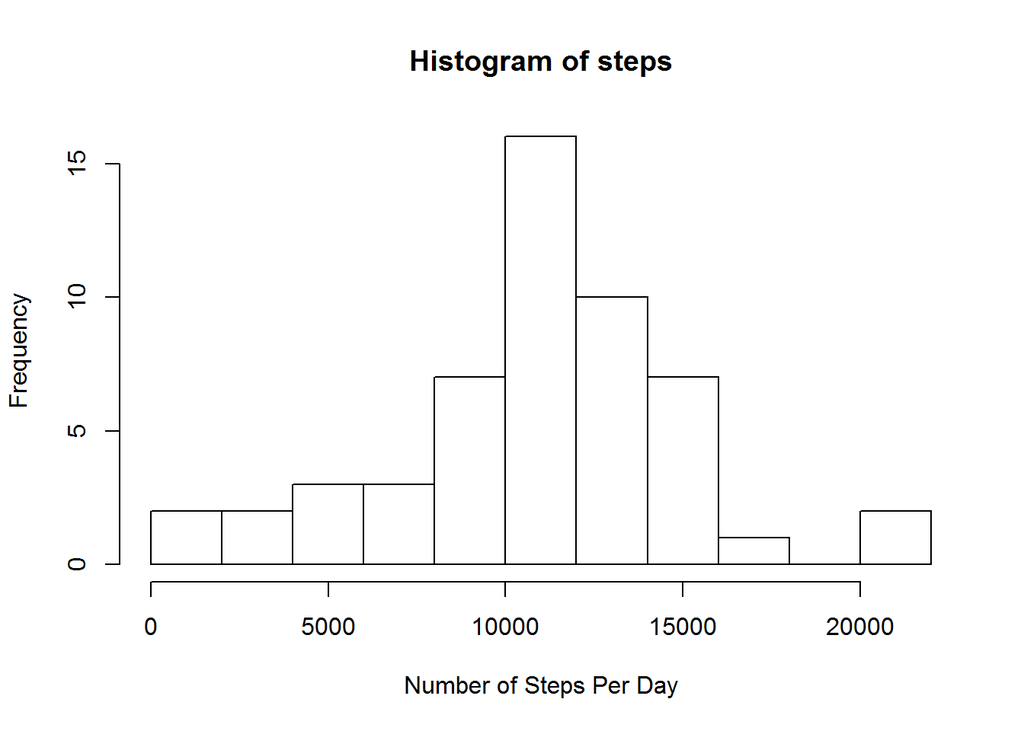

```r
        activityRmNa$date <- factor(activityRmNa$date)
        steps <- numeric()
        i = 1
        for( date in levels(activityRmNa$date) ){
                steps[i] <- sum(activityRmNa[activityRmNa$date==date,]$steps)
                i = i + 1
        }
        hist(steps,breaks=10,xlab="Number of Steps Per Day")
```

```r
        summary(steps)
```

```
##    Min. 1st Qu.  Median    Mean 3rd Qu.    Max.
##      41    8840   10800   10800   13300   21200
```

The mean number of steps is 1.0766 × 10<sup>4</sup> per day. The median number of steps is 1.0765 × 10<sup>4</sup> per day.

A averaged time serieis plot of time interval is given below.

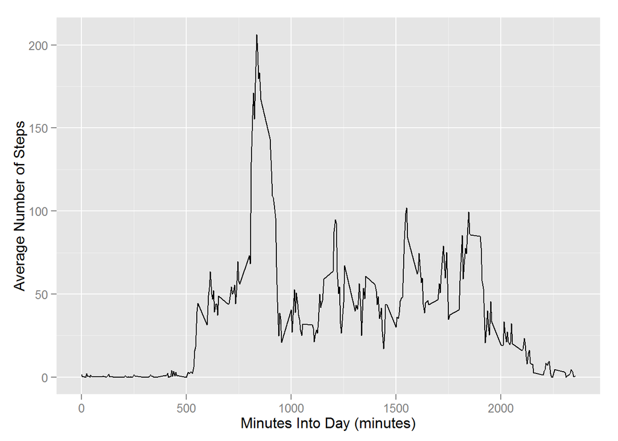

```r
        activityRmNa$interval <- factor(activityRmNa$interval)
        meanSteps <- numeric()
        intervals <- numeric()
        i = 1
        for( int in levels(activityRmNa$interval) ){
                meanSteps[i] <- mean(activityRmNa[activityRmNa$interval==int,]$steps)
                intervals[i] <- as.numeric(int)
                i = i + 1
        }
        df <- data.frame(interval=intervals,avgSteps = meanSteps)
        library(ggplot2)
        qplot(interval,avgSteps,data=df,geom="line",xlab="Minutes Into Day (minutes)", ylab="Average Number of Steps")
```

Lets replace the NA values with mean value for that time.

```r
        for( i in 1:length(activity$steps) ){
                if( is.na(activity[i,]$steps) ){
                        activity[i,]$steps = df[df$interval==activity[i,]$interval,]$avgSteps
                }
        }
         head(activity)
```

```
##     steps       date interval
## 1 1.71698 2012-10-01        0
## 2 0.33962 2012-10-01        5
## 3 0.13208 2012-10-01       10
## 4 0.15094 2012-10-01       15
## 5 0.07547 2012-10-01       20
## 6 2.09434 2012-10-01       25
```

```r
         tail(activity)
```

```
##        steps       date interval
## 17563 2.6038 2012-11-30     2330
## 17564 4.6981 2012-11-30     2335
## 17565 3.3019 2012-11-30     2340
## 17566 0.6415 2012-11-30     2345
## 17567 0.2264 2012-11-30     2350
## 17568 1.0755 2012-11-30     2355
```

The new histograms and summarys are as follows:

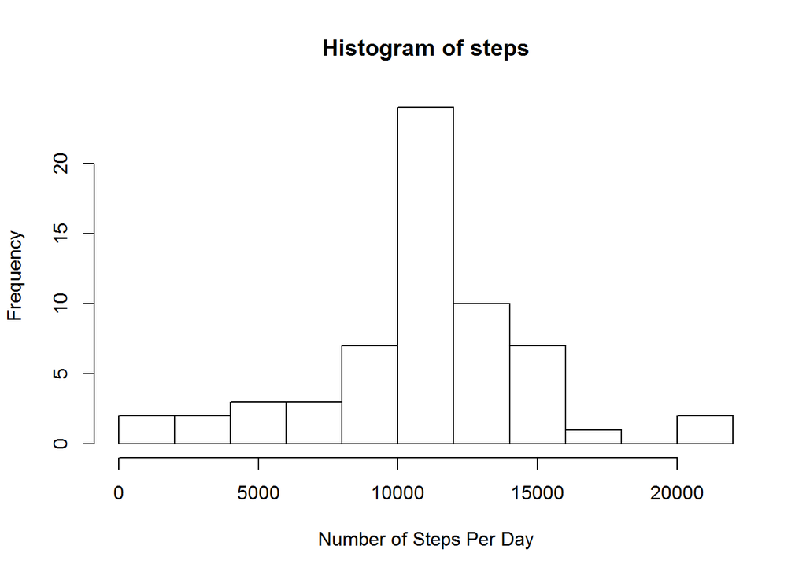

```r
        activity$date <- factor(activity$date)
        steps <- numeric()
        i = 1
        for( date in levels(activity$date) ){
                steps[i] <- sum(activity[activity$date==date,]$steps)
                i = i + 1
        }
        hist(steps,breaks=10,xlab="Number of Steps Per Day")
```

```r
        summary(steps)
```

```
##    Min. 1st Qu.  Median    Mean 3rd Qu.    Max.
##      41    9820   10800   10800   12800   21200
```

The new mean number of steps with the imputed data is 1.0766 × 10<sup>4</sup> per day. The new median number of steps is 1.0766 × 10<sup>4</sup> per day. These are both very close to the originals.

Now we will look at the trends of the data over weekdays and weekends.

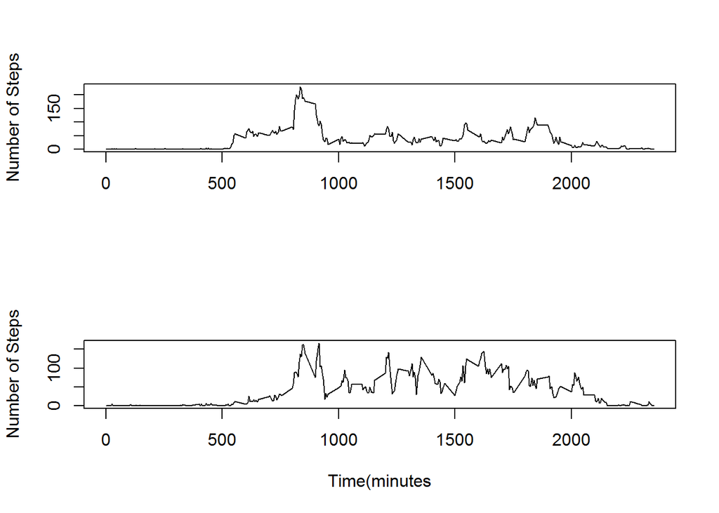

```r
        weekend = weekdays(as.Date(activity$date))=="Sunday" | weekdays(as.Date(activity$date)) == "Saturday"

        weekdayActivity <- activity[!weekend,]
        weekendActivity <- activity[weekend,]

        weekdayActivity$interval <- factor(weekdayActivity$interval)
        weekdayMeanSteps <- numeric()
        intervals <- numeric()
        i = 1
        for( int in levels(weekdayActivity$interval) ){
                weekdayMeanSteps[i] <- mean(weekdayActivity[weekdayActivity$interval==int,]$steps)
                intervals[i] <- as.numeric(int)
                i = i + 1
        }
        weekdayDf <- data.frame(interval=intervals,avgSteps = weekdayMeanSteps)

        weekendActivity$interval <- factor(weekendActivity$interval)
        weekendMeanSteps <- numeric()
        intervals <- numeric()
        i = 1
        for( int in levels(weekendActivity$interval) ){
                weekendMeanSteps[i] <- mean(weekendActivity[weekendActivity$interval==int,]$steps)
                intervals[i] <- as.numeric(int)
                i = i + 1
        }
        weekendDf <- data.frame(interval=intervals,avgSteps = weekendMeanSteps)
        library(ggplot2)
        par(mfrow=c(2,1))
        plot(weekdayDf$interval,weekdayDf$avgSteps,type="l",ylab="Number of Steps",xlab="")
        plot(weekendDf$interval,weekendDf$avgSteps,type="l",ylab = "Number of Steps",xlab="Time(minutes")
```